# R Notebook

loading libraries

loading in the data

```r
project <- read_csv("project_management.csv")
```

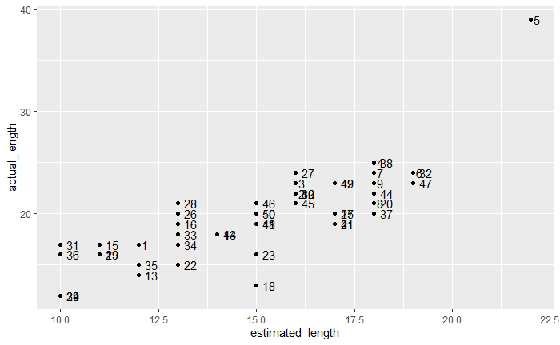

outliers eyeballed from this graph: influential: 5 non-influential: maybe 18, maybe 24

```r
proj_model <- lm(formula = actual_length ~ actual_length, data = project)
```

```
the response appeared on the right-hand side and was droppedproblem with term 1 in model.matrix: no columns are assigned
```

[figure not shown]

There aren’t any Cook’s distance lines in this plot. Plotting a Cook’s Distance plot to check which outliers are influential

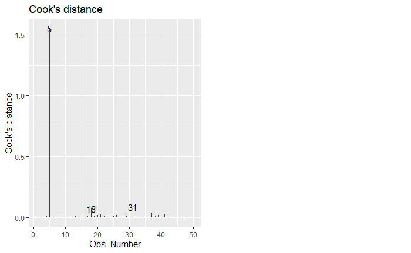

clearly 5 is a massively influential outlier. 18 and 31 are influential outliers too, but not much.

now plotting the data points, and both regressions obtained so far.

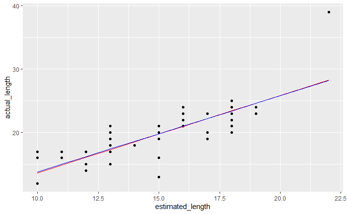

the intercept and regression coefficient of the two models are not that different at all. I’d stand by the point that point 24 is non influential.

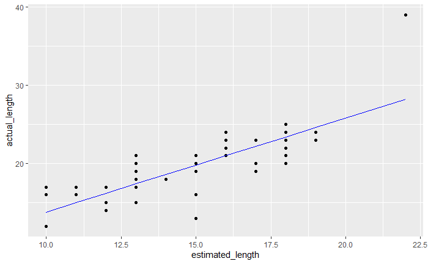

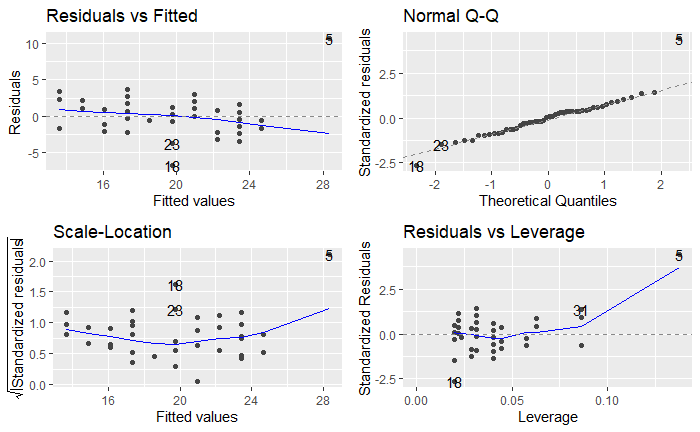

thte Residuals vs Fitted plot os mostly centred around 0. It has a slight downward slope towards the right. It’s mostly pretty alright, but pointg number 5 is an obvious outlier, and potentially a problem. Point 18 is also an outlier, that might be influential.

the normal q-q plot shows that the residuals are mostly normally distributed, with the exceptions of 5 (it’s always 5 causing problems), and 18.